# The Bancor Pricing Algorithm

Based on the whitepaper from: Eyal Hertzog, Guy Benartzi, Galia Benartzi, "The Bancor Protocol" March, 2018

8/22/18

by: gunnar pope

gunnarpope@gmail.com

Written for: Horuspay.io

### Definitions and notes on the Bancor Algorithm:

Use the definition of $TOK$ for the Smart Token symbol and $CTOK$ for the connector token that you wish to transfer.

#### Connector Weight

From the Price Formula algorithms:

$$ CW = \frac{ConnectorBalance}{SmartTokenTotalValue}$$ Where, $ConnectorBalance$ is the balance of the toconnector tokens in the connector account and $SmartTokenTotalValue$ is the market cap of the Smart token implementing the Bancor algorithm.

$$SmartTokenTotalValue= price*TotalTOKSupply$$

Where $price$ is in units of [USD/TOK] and $SmartTokenSupply$ is the maximum amount of $TOK$ tokens.

#### Token Price

$$OutstandingTOKSupply = TotalTOKSupply - CirculatingTOKSupply$$

The Whitepaper defines an algorithm for determining the price of $TOK$ by:

$$ price = \frac{CTOKBalance}{OutstandingTOKSupply*CW}$$

This formula must be in units of $[CTOK/TOK]$, and is uses $CW$ to scale the price ratio. CTOKbalance is $[CTOK]$ and $OutstandingTOKSupply$ is in $[TOK]$.

This formula implies that if there is a large outstanding supply (low demand), the token will be worth a fraction of it's marketcap price and if only a few tokens are available in supply (high demand), each token will be worth nearly the marketcap price.

#### Tokens Issued

$$ TOKissued = TOKsupply*\big((1+(\frac{CTOKpaid}{CTOKbalance})^{CW}-1\big)$$

This is the amount of Smart Tokens to payout given the current smart token supply, $TOKsupply$, the connected tokens paid, $CTOKpaid$, and the balance of $CTOK$ tokens in the bancor account, $CTOKbalance$.

$$ CTOKpaidout = CTOKbalance * ((1+\frac{TOKdestroyed}{TOKsupply})^{\frac{1}{CW}}-1) $$

The effective price can be calculated as:

$$ effectivePrice [CTOK/TOK] = \frac{CTOKexchanged}{TOKexchanged}$$

The $effectivePrice$ represents the effective exchange rate of the transaction, in units of $[CTOK/TOK]$

```python
# The Bancor Algorithm and testing
class smart_token:
    def __init__(self, name, circulatingsupply, totalsupply , price):
        self.name = name
        self.circulatingsupply = circulatingsupply
        self.totalsupply = totalsupply
        self.price = price                   # USD/HORUS
        self.marketcap = price * totalsupply # USD/HORUS*TOKsupply

    def get_marketcap(self):
        return (self.price * self.totalsupply)

    def get_outstandingsupply(self):
        return(self.circulatingsupply)

    def printtok(self):
        print("Token Stats:")
        print("Token: ", self.name)
        print("circulatingsupply: ", self.circulatingsupply)
        print("totalsupply: ",  self.totalsupply)
        print("price: ", self.price )
        marketcap = self.get_marketcap()
        print("marketcap: ", marketcap ," USD")
        outstandingsupply = self.get_outstandingsupply()
        print("outstandingsupply: ", outstandingsupply)


class connector:
    def __init__(self, tokenname, balance, price):
        self.token   = tokenname   # name="TOK", for example
        self.balance = balance     # the balance of token "TOK" remaining
        self.price   = price       # USD/TOK
        self.balanceValue = self.price*self.balance


    def get_balanceValue(self):
         return (self.price * self.balance)

    def printcon(self):
        print("Connector Stats:")
        print("Token: ", self.token)
        print("Balance: ", self.balance)
        print("Price: ",  self.price)
        balance = self.get_balanceValue()
        print("BalanceValue: ", balance ," USD" )



class Bancor:
    def __init__(self):
        price = 0
        effectiveprice = 0
        self.tokensissued   = 0
        self.ctokrecieved   = 0
        self.tokensreceived = 0
        self.ctokissued     = 0
        self.effectiveCTOKtoTOKprice = 0
        self.effectiveTOKtoCTOKprice = 0

    def reset(self):
        price = 0
        effectiveprice = 0
        self.tokensissued   = 0
        self.ctokrecieved   = 0
        self.tokensreceived = 0
        self.ctokissued     = 0
        self.effectiveCTOKtoTOKprice = 0
        self.effectiveTOKtoCTOKprice = 0

    def ctoktotok(self, ctokrecieved):
        self.ctokrecieved = ctokrecieved

    def toktoctok(self, tokrecieved):
        self.tokrecieved = tokcieved


    def get_CW(self, tok, ctok):
        CW = ctok.balance / tok.marketcap
        return (CW)

    def priceCTOKtoTOK(self, tok, ctok):
        CW = self.get_CW(tok, ctok)
        balance = ctok.balance
        outstandingsupply = tok.get_outstandingsupply()

        self.price = balance/(outstandingsupply*CW)

        return ( self.price )

    def TOKissued(self, tok, ctok, ctokrecieved):
        TOKsupply   = tok.totalsupply
        CTOKpaid    = ctokrecieved
        CTOKbalance = ctok.balance
        CW = self.get_CW(tok, ctok)

        self.tokensissued = TOKsupply*( (1+CTOKpaid/CTOKbalance)**(CW) -1)
        # subtract this from the token balance
#         tok.outstandingsupply -= self.tokensissued
        self.effectiveCTOKtoTOKprice = ctokrecieved / (1.0*self.tokensissued)

        return (self.tokensissued)

    def CTOKpaidout(self, tok, ctok, tokrecieved):
        TOKdestroyed = tokrecieved
        TOKsupply    = tok.circulatingsupply # is this the available or total supply number?
        CTOKbalance  = ctok.balance
        CW = self.get_CW(tok, ctok)
        self.ctokissued = CTOKbalance*( (1+ TOKdestroyed/TOKsupply)**(1/(CW)) -1)

        print("tokrecieved: ", tokrecieved)
        self.effectiveTOKtoCTOKprice = tokrecieved / (1.0*self.ctokissued)

        return (self.ctokissued)




###########################################


# eoscon.price = 1
# eoscon.get_balanceValue()

# find the supply of HORUS on the EOS MAINNET
# $ cleos --url https://api.eosnewyork.io:443  get currency stats horustokenio "HORUS"
# {
#   "HORUS": {
#     "supply": "1200000000.0000 HORUS",
#     "max_supply": "1200000000.0000 HORUS",
#     "issuer": "horustokenio"
#   }
```

```python
# on 8/22/18, the current HORUS price is:
# USDtoHORUS  = 0.0031 # in units of USD/HORUS
USDtoHORUS  = 1 # in units of USD/HORUS
print("USDtoHorus", USDtoHORUS)


# Initialize your smart token, (use an estimated circulation of 10000 HORUS)
HORUSsupply = 1000.0000
HORUScirc   = 1000.0000

horus = smart_token("HORUS", HORUScirc, HORUSsupply, USDtoHORUS)

EOSbalance = 0.5*horus.marketcap # this creates a CW of 0.50
USDtoEOS = 1
eoscon = connector("EOS",EOSbalance,USDtoEOS)
# eoscon.balance = 0.5* horus.marketcap# explicitly set this for testing

bancor = Bancor()

print("Horus Market Cap", horus.marketcap)

# The connector weight
CW = bancor.get_CW(horus, eoscon)
print("The Connector Weight: ", CW)

# bancor pricing
CTOKtoTOK = bancor.priceCTOKtoTOK(horus, eoscon)
print("Get the Price [CTOK/TOK]", CTOKtoTOK)


print("\nTransfer CTOK to TOK")
EOSrecieved = 10 #EOS
print("EOS recieved: ", EOSrecieved)
TOKissued = bancor.TOKissued(horus, eoscon, EOSrecieved)
print("TOK tokens issued to buyer: ", TOKissued)
print("The effective [CTOK/TOK] price: ", bancor.effectiveCTOKtoTOKprice)

bancor.reset()


print("\nTransfer TOK to CTOK")
TOKrecieved = 10.000 #HORUS
CTOKpaidout = bancor.CTOKpaidout(horus, eoscon,TOKrecieved)
print("CTOK tokens issed to buyer: ", CTOKpaidout)
print("The effective [TOK/CTOK] price: ", bancor.effectiveTOKtoCTOKprice)
```

```
USDtoHorus 1
Horus Market Cap 1000.0
The Connector Weight:  0.5
Get the Price [CTOK/TOK] 1.0

Transfer CTOK to TOK
EOS recieved:  10
TOK tokens issued to buyer:  9.95049383620783
The effective [CTOK/TOK] price:  1.0049752469181004

Transfer TOK to CTOK
tokrecieved:  10.0
CTOK tokens issed to buyer:  10.050000000000004
The effective [TOK/CTOK] price:  0.9950248756218901
```

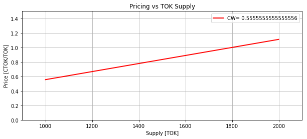

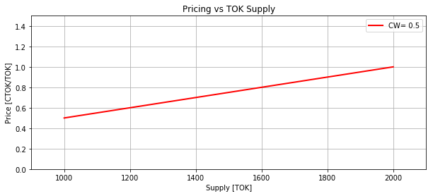

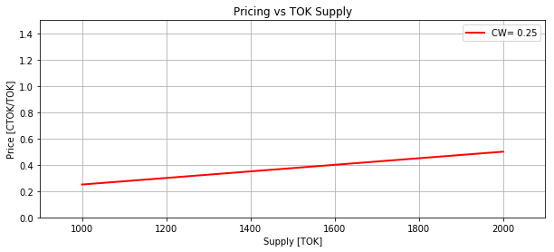

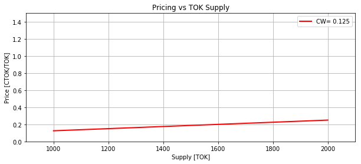

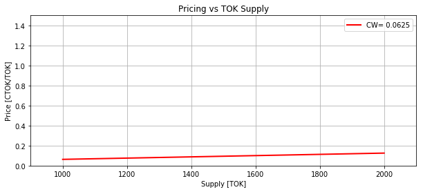

```python
# Initialize your smart token, (use an estimated circulation of 10000 HORUS)
import numpy as np
import matplotlib.pyplot as plt

HORUSsupply = 2000.0000
HORUScirc   = 2000.0000

USDtoEOS    = 1


horus_supply = np.linspace(1000,2000,1000)
EOSbalance = 1000 #USD of EOS



USDtoHORUSlist  =  [0.9, 1, 2, 4, 8]

for USDtoHORUS in USDtoHORUSlist:

    pricing    = []
    for supply in horus_supply:

        horustok   = smart_token("HORUS", supply, HORUSsupply, USDtoHORUS)

        eostok     = connector("EOS",EOSbalance,USDtoEOS)
        banc = Bancor()

        # The connector weight
        CW = banc.get_CW(horustok, eostok)

    #     print("The Connector Weight: ", CW)

        # bancor pricing
        CTOKtoTOK = banc.priceCTOKtoTOK(horustok, eostok)
        TOKtoCTOK = 1/CTOKtoTOK
        pricing.append(TOKtoCTOK)



    plt.figure(figsize=(10,4))
    plt.plot(horus_supply, pricing,'r', linewidth=2,label="CW= "+str(CW))
    plt.title("Pricing vs TOK Supply")
    plt.legend()
    plt.ylabel("Price [CTOK/TOK]")
    plt.xlabel("Supply [TOK]")
    plt.axis([900,2100,0,1.5])
    plt.grid(True)
    plt.show()

    del horustok, banc, eostok

del pricing
```

## Conclusion

The basics of the bancor algorithm are listed above. These plots don't match the Bancor whitepaper exactly so we should see where their algorithm differs from ours. Some of the variables used in the whitepaper are not explicitly defined so we had to assume that outstandingTOKbalance = circulatingTOKsupply, etc..